# Supplementary to How WEIRD-biased is CHILDES' data on children's linguistic input? Appendix 1: Further acknowledgments, knitted analyses and supplementary analyses with a different implementation of Education

# Load annotations

```
## [1] "Faroe Islands"
```

## Introduction

We classified countries as Western and Democratic. For Western, we classified as Western all of the countries in Western Europe (according to EuroVoc: Andorra, Austria, Belgium, France, Germany, Ireland, Liechtenstein, Luxembourg, Monaco, Netherlands, Switzerland, United Kingdom) as well as a few others in Europe (Italy, Portugal, Spain, Norway, Sweden, Iceland, Denmark), most of North America (with the exception of Bermuda and Greenland), and two countries in Oceania (Australia, New Zealand). This resulted in 20 Western and 223 non-Western countries. For democratic, we simplified the OWID’s classification of closed and electoral autocracies into autocracies, versus electoral and liberal democracies into democracies (Our World in data, 2022c). We had data on political regime for 178 countries (from Our World in Data, OWID, 2011); on the proportion of the population having completed lower secondary school 178 (from OWID, 2007-2014); on GDP for 189 countries (from WDI, 2011); on the proportion of the population that was urban for 212 countries (from WDI, 2011); on fertility for 199 countries (from OWID, 2011).

### Figures 1 & 2

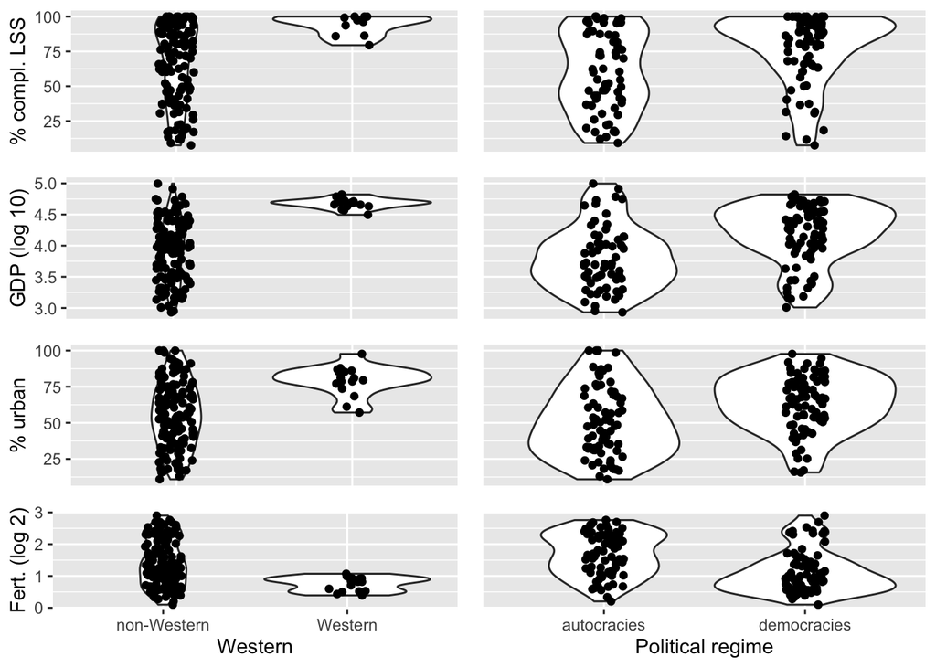

Evidence that values in the multidimensional WEIRD complex are only partially correlated (continued). Violin plots of continuous variables as a function of the two discrete variables: Western and type of political regime. Education is represented by proportion of the population completing lower secondary school; industrialization by percentage of the population living in urban (as opposed to rural) sites; richness by GDP per capita. In addition, we show women’s average total fertility.

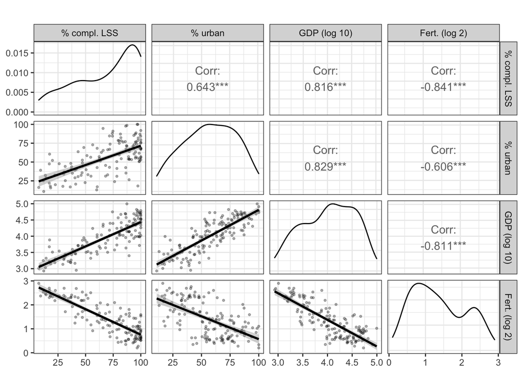

### Text

The answer to the question of who surrounds the child may also depend on how large the nuclear family is. There is considerable cross-population variation in terms of the average number of children a woman has in her reproductive lifetime, varying between a little over 1 (

|  | country | Fertility |
| --- | --- | --- |
| 228 | Taiwan | 1.07 |

) to over 6 (

|  | country | Fertility |
| --- | --- | --- |
| 141 | Niger | 7.46 |

).

## Methods info

A total of 321 corpora were initially considered. We excluded 10 because at least some of the children were not typically developing; 22 because data was collected in the lab or school; 9 because data was not available; 19 because only the child was transcribed; 11 because they were diary studies; 67 because speech was triggered by a task (elicitation, story-telling, etc.); 3 because the conversation involved exclusively unfamiliar adults. After these exclusions, 180 remained. The following analyses will continue only on these included corpora.

### Table 2

```
##        country       Compl.LS SP.URB.TOTL.ZS        log_gdp      log2_fert
##            180            114            175            175            176
```

### Table 3

```
##                                 Education.STDZD
##                                              80
##                                       SES.STDZD
##                                             102
##                             Parental.profession
##                                              98
##      Language.or.Languages.spoken.in.recordings
##                                             180
##          Bilingualism.Multilingualism.in.corpus
##                                             110
## Type.of.community.at.the.time.of.the.recordings
##                                              65
##                             Household.structure
##                                              68
##                        Proportion.With.Siblings
##                                              93
##                      Average.number.of.siblings
##                                              83
```

## Results

### Country-level variables

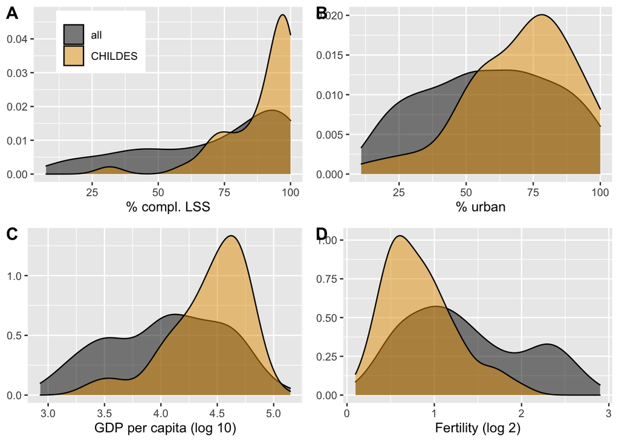

Figure 3: Density plots showing the distribution of country-level descriptors for all countries (dark gray) versus countries represented in CHILDES (orange). GDP stands for Gross Domestic Product. Percent completed lower secondary school is the percent of the country’s population completing lower secondary school. Percent urban is the percent of the country’s population residing in urban (as opposed to rural) locations. Total fertility rate is the average number of children a woman has over her whole reproductive period.

Using country-level statistics, we were able to assess the extent to which the countries with data in CHILDES were a representative sample of countries in the world. Density plots are portrayed in Figure 3. The means for each of the variables differed for the countries in CHILDES versus overall in the world using unpaired samples t-tests without assuming equality of variance (Welch’s t). Countries in CHILDES had a higher proportion of the population completing lower secondary school than the world wide sample (% compl. LSS, t(101.59)=-5.79, p = 0); they were more urban (% urban, t(79.77)=-3.51, p = 0); richer (log GDP per capita, t(103.29)=-6, p = 0) and had lower fertility rates (log fertility, t(117.09)=6.85, p = 0).

### Corpus-level variables

Education information was missing for more than half of the corpora (see Table 3); and 4 were described as diverse, without clarifying the range of education covered. Of the remaining 76 samples, 3 had at least some parents with primary-level education; 9 had parents with secondary school education as the lower bound of the education range, and a further 6 had some college as the lower bound. Thus, 76% of the samples (N = 58) portrayed children whose parents had at least a graduate, if not a postgraduate, degree. Samples were not representative of the countries they were collected, since in those same countries the proportion of the population with tertiary education was only 16%.

We then turned to the additional factors, starting with how varied language backgrounds were. A total of 62 different languages or language combinations (for bilingual and multilingual children) were reportedly spoken in the corpora. The samples in which only one language was reported spoke Afrikaans, Arabic (Egyptian or Kuwaiti), Basque, Cantonese, Catalan, Cree, Croatian, Czech, Danish, Dutch, English, Estonian, Farsi, French, German, Greek, Hebrew, Hungarian, Icelandic, Indonesian, Irish, Italian, Jamaican, Japanese, Korean, Mandarin, Norwegian, Nungon, Polish, Portuguese (Brazilian or European), Romanian, Russian, Serbian, Sesotho, Slovenian, Spanish, Swedish, Taiwanese, Tamil, Thai, Turkish, Welsh, and the samples in which multiple languages were reported spoke Catalan/Spanish, Dutch/English, Dutch/French, Dutch/Italian, English/Cantonese, English/Dutch, English/French, English/Hebrew, English/Japanese, English/Japanese/Danish, English/Mandarin, English/Mandarin/Cantonese, English/Russian, English/Spanish, French/Russian, German/Spanish, Hungarian/Catalan/Spanish, Hungarian/Farsi/English, Italian/German, Italian/Japanese, Portuguese/Swedish/English, Spanish/Catalan, Spanish/English, Spanish/Galician.

About a third (32%) of the included corpora that had available data for this variable (N = 110) were not monolingual. It is hard to find reliable estimates of the percentage of the population who are not monolingual in the world or in the countries represented in CHILDES, but for instance, in Europe in 2016, 65% of adults reported knowing multiple languages (Eurostat, 2022). According to such estimates, even if samples are linguistically diverse, it would appear that input data in CHILDES under-represents bilinguals and multilinguals.

As for family structure, 60 corpora (88% of those that had data for this variable) were based on nuclear families; in 7 extended families were portrayed; and in 1 one sample the structure was varied. We do not know of a country-level index that would allow us to check whether CHILDES corpora are representative of their countries for this variable.

A majority of corpora in CHILDES include children who have siblings. In fact, only 28% of samples (among the 93 corpora having information on siblings) were constituted exclusively by children with no siblings, and the remaining had at least one sibling, with the overall average being 0.8 siblings. Since 83% of countries in CHILDES are in the OECD, we draw a comparison point for such countries: 46% of children had no siblings in OECD countries according to 2015 data. In this sense, children with multiple siblings appear to be over-represented in CHILDES.

## Discussion

Table 4. Low variability makes it difficult to tease apart empirically dimensions like family size and parental education: It may be reasonable to compare the input afforded to children who have at least one sibling (1+) versus none for samples consisting of parents with a completed college education, but families with lower levels of education are too under-represented to allow a meaningful study. NA indicates missing values for this variable.

```
##
##                     None 1+ NA
##   Some primary         0  3  0
##   Some secondary       1  8  0
##   Some college         1  3  2
##   College and above   18 26 14
##   NA                   6 27 71
```

## Additional analyses

Figures on education using WDI’s proportion of the population completing high school (rather than Our world in data’s proportion of the population completing lower secondary school).

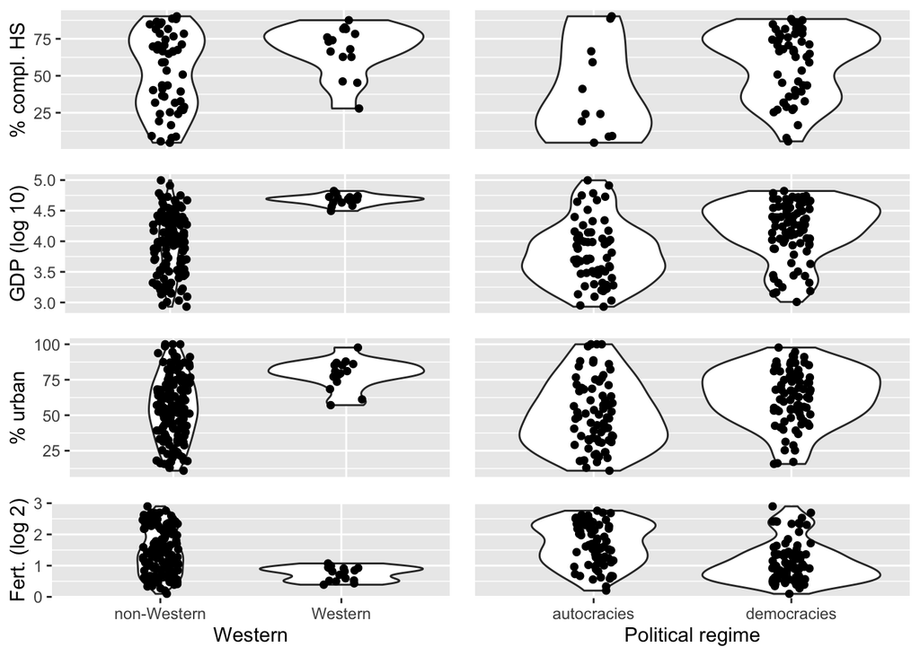

Equivalent to Fig 1, only the education variable has changed.

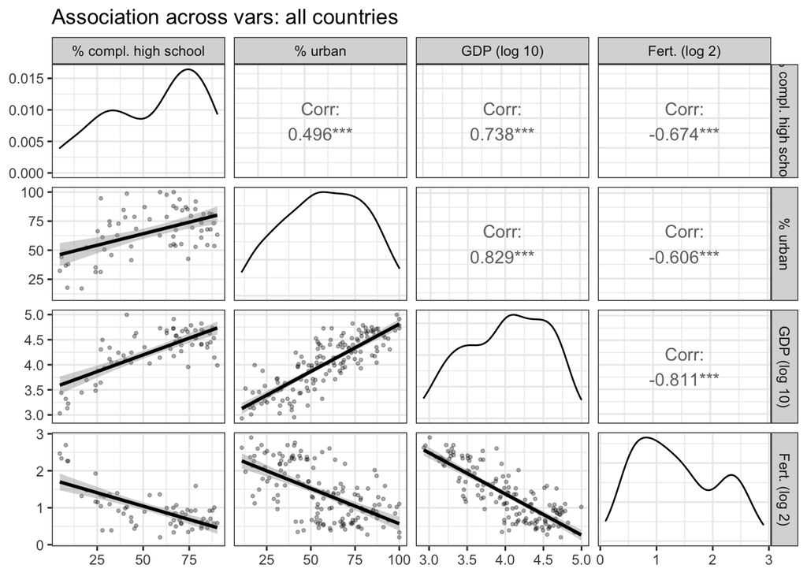

Equivalent to Fig 2, only the education variable has changed.

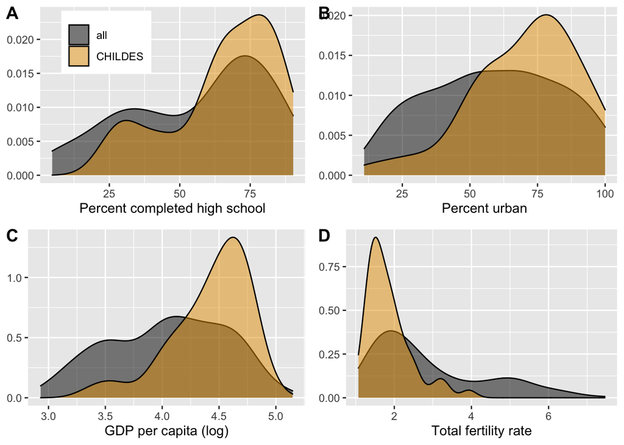

### Supplementary recommendations for CHILDES

As represented in the Figure below, CHILDES corpora can have two levels of metadata, one at the speaker level and the other at the level of the corpus as a whole. At present, nearly none of the fields are mandatory and seldom filled in. The standardized (yet optional) fields in speaker-level metadata include several fields that would be relevant to the study of diversity in CHILDES, including: language, age, sex, socioeconomic status (WC for working class, UC for upper class, MC for middle class, LI for limited income), role (relationship to the child), and education (in years). At the corpus level, there are already variables to encode the type of activity recorded (interactivity, planning type, involvement, social context, event structure, and task) as well as information about location (at the continent and country levels). There is, at present, no way to signal the geographic origin of CHILDES data more finely, but if this information were added, then we could assess the extent to which localities where education is widespread are over-represented; and the extent to which unusually well-educated parents are over-represented. Perhaps a reasonable goal is to attempt to match the world’s distribution in terms of simple educational metrics, like having completed lower secondary school.

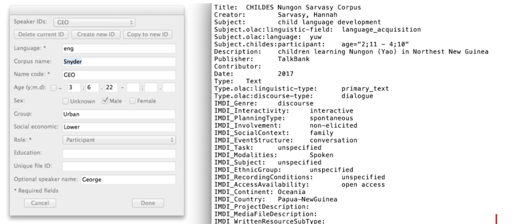

Metadata found in CHILDES corpora. The left panel shows a selection of speaker-level metadata fields (reproduced from p. 35 of the CHAT Manual, MacWhinney, 2000). The variable Group can contain any grouping relevant to the corpus producers. The right panel shows corpus-level metadata for Sarvasy (2017).

Incorporating these other metrics would require not only adding fields to the CHILDES’ metadata system, but also developing training materials to ensure that all CHILDES contributors provide information in a standardized way. The extra effort required to implement this could be measured with a small number of volunteers before making it a requirement for data deposit, to both check for feasibility and ensure that the benefits of considering and tracking this information outweigh the costs.

## Further acknowledgments

We would like to thank the curators of the corpora who replied to our email: , , Andra Kütt, Caroline Rowland, Carrie Dyck, David Dickinson, Dominique Bassano, Juana Liceras, Klára Matiasovitsová, Luigi Rizzi, Maria João Freitas, Michelle McGillion, Sanne Kuijper, Sinead McNally, Tina Hickey, Ur Shlonsky, Zhang Yibin, Amy Strekas, Donna Thal , Frank Wijnen, Gaja Jarosz, Gerardo Aguado Alonso, Jane Herbert, Jasmina Moskovljević Popović, Jing Zhou, Pilar Prieto, Rebecca Burns, Stephen Matthews, Teresa da Costa, Ulrich Frauenfelder, Uri Tadmor, Virginia Yip, Yvan Rose, Ana Isabel Ojea Lopez, Andra Kütt, Bob Wilson, Christophe Parisse, Elena Lieven, Elena Nicoladis, Elizabeth Nixon, Filip Smolik, Folkert Kuiken, Huang Yue-Yuan, Janet Bang, Jeannine Goh, Julian Pine, Linhui Li, Luigi Rizzi, Maja Roch, Mara Steinberg Lowe, Marguerite Mackenzie, Michelle White, Nada Ševa, Nicola Botting, Stephanie Durrleman, Stephen Matthews, Virginia Yip, Yvan Rose, 404 Not Found, Airi Kapanen, Alan Cruttenden, Alison Henry, Aliyah Morgenstern, Amye Warren-Leubecker, Ana Lúcia Santos, Ana Maria Guimarães, Andra Kütt, Andrea Biró, Andrea Feldman, Angela Grimm, Ann Peters, Anna Chromá, Anna Theakston, Anne Van Kleeck, Anne-Marie Schaerlaekens, Annick De Houwer, Annick DeHouwer, Antje van Oosten, Aparna Nadig, Astrid Klammler, Aurora Bel Gaya, Aviya Hacohen, Ayhan Aksu Koç, Barbara Davis, Barbara Pearson, Bernadette Plunkett, Bernd Möbius, Bob Jones, Brian MacWhinney, Britta Lintfert, Carina Koroschetz, Carmen Silva-Corvalán, Caroline Rowland, Catherine Snow, Cécile De Cat, Charles Watkins, Chiara Roggero, Chien-ju Chang, Christian Champaud, Christiane von Stutterheim, Christina Gildersleeve-Neumann, Christine Howe, Claartje Levelt, Claudine Hammelrath, Colleen Huebner Morisset, Conxita Lleo, Conxita Lleó, Cornelia Hamann, Darinka Anđelković, David Gil, Dmitar Popov, Donella Antelmi, Donna Jackson-Maldonado, Dorit Ravid, Eithne Guilfoyle, Ekaterina Protassova, Elena Pizzuto, Elena Tribushinina, Elena V. M. Lieven, Elisabet Serrat Sellabona, Eliseo Diez-Itza, Elizabeth Bates, Eon-Suk Ko, Eva Bar-Shalom, Eve Clark, Evelien Krikhaar, Feyza Altinkamis, Francisco De Lacerda, Frank Wijnen, Fred Genesee, Frenette Southwood, Gerard Bol, Ghada Khattab, Gina Conti-Ramsden, Gisela Szagun, Giuseppe Cappelli, Gordana Hržica, Gordon Wells, Habibeh Samadi, Hanna Batoréo, Hannah Sarvasy, Harriet Jisa, Heather Goad, Heba Salama, Heidi Feldman, Heike Behrens, Helen Körgesaar, Hervé Hunkeler, Hintat Cheung, Hiro Yuki Nisisawa, Hrafnhildur Ragnarsdóttir, Hye-Ree Ghim, Igor Žagar, Iliana Reyes, Inge Zink, Ioana Goga, Isabelle Barrière, Isabelle Maillochon, Jacqueline Sachs, Jacqueline van Kampen, Jan Edwards, Jane S. Tsay, Javier Aguado Orea, Jean Berko Gleason, Jean Quigley, Jean-Adolphe Rondal, Jeannine Goh, Jeroen Aarssen, Jing Zhou, Jody Tommerdahl, Joe Pater, Johanna Nicholas, Jóhanna Thelma Einarsdóttir, Johanne Paradis, John Neil Bohannon III, Jordan Zlatev, José L. Linaza, Ju-Yeon Ryu, Judit Navracsics, Julian Pine, Julie Brittain, Julie McMillan, Jürgen Weissenborn, Kaja Kohler, Karina Hess Zimmermann, Karme Beek, Katerina Palasis, Katherine Demuth, Katherine Nelson, Kathy Post, Keith Sawyer, Kim Plunkett, Klaus Wagner, L. Haggerty, Laetitia de Almeida, Larisa Avram, Larry F. Guthrie, Leonor Scliar-Cabral, Liliana Tolchinsky, Linda Kelly, Linhui Li, LinHui Li, Lise Menn, Livia Tonelli, Lois Bloom, Lori Van Houten, Lorraine McCune, Lynn S. Bliss, Madalena Cruz-Ferreira, Madeleine Leveillé, Magda Krupa-Kwiatkowska, Magdalena Smoczynska, Maigi Vija, Maja Roch, Manuela Wagner, Marc Bornstein, Margaret Deuchar, Maria del Carmen Aguirre Martínez, Maria Emma Ticio, María Jesús Pérez-Bazán, Maria-Llanos Luque Sánchez, Marie-Thérèse Le Normand, Mariko Hayashi, Marilyn Vihman, Marta Fernández Vázquez, Martha Shiro, Marty Demetras, Mary Ann Evans, Mary Beckman, Mary Erbaugh, Masayuki Yokoyama, Mats Andrén, Max Miller, Megan Devlin, Melanie Soderstrom, Melissa Redford, Melita Kovacevic, Michael Brent, Michael Forrester, Milagros Fernández Pérez, Miquel Serra, Mirco Fasolo, Mireas Llinas, Mireia Llinàs-Grau, Mitsuhiko Ota, Mohamed Lahrouchi, Monique Vion, Myron Korman, Nan Bernstein Ratner, Naomi Hamasaki, Naomi Yamaguchi, Natalia Gagarina, Neil Smith, Neiloufar Family, Nina Gram Garmann, Norio Naka, Not Found, Núria Esteve-Gibert, Oksana Bailleul, Ondene Van Dulm, Oralia Rodríguez Arredondo, Outi Bat-El, Pamela Rollins, Patrick Suppes, Paul Fletcher, Paula Fikkert, Péter Bodor, Petra Bos, Petra Hendriks, Petra Sleeman, Rangaswamy Narasimhan, Raquel Fernández Fuertes, Reili Argus, Richard Sprott, Richard Weist, Roberto Soto Valle, Roger Brown, Ron Gillam, Rosa Graciela Montes, Roy Higginson, Ruth Berman, Sam Leung, Seba Al-Hindawy, Shaima AlQattan, Sharon Inkelas, Silvia Nieva, Silvia Romero Contreras, Sirli Zupping, Sophie Kern, Sotaro Kita, Stan Kuczaj, Steven Gillis, Sudaporn Luksaneeyanawin, Susan Ellis Weismer, Susan Gelman, Susan R. Braunwald, Susana Correia, Susana López Ornat, Susanne Miyata, Sven Strömqvist, Takeo Ishii, Tamirand De Lisser, Tania Ionin, Thea Cameron-Faulkner, Thomas Doukas, Thomas Lee, Tina Ringstad, Twila Tardif, Ursula Stephany, Valentin Remedi, Victoria Marrero, Virginia C. Gathercole, Virginia Gathercole, Virginia Valian, Virginia Yip, William Hall, William Snyder, Xiangjun Deng, Yasuhiro Shirai, Yonata Levy, Yoshiki Ogawa, Yow Wei Quin, and Yow Wei Quin.